# Hands-On Example: Mapping from SDTM to ADaM Using R and Handling Missing Data with Multiple Imputation

Author

Joshua J. Cook

Published

October 21, 2024

## Objective

The goal of this section is to transform our SDTM dataset into an ADaM (Analysis Data Model) dataset that is CDISC-compliant while **handling missing data with multiple imputation**. This ensures that our clinical data is ready for statistical analysis and reporting, following CDISC ADaM standards.

## Step-by-Step Transformation from SDTM to ADaM with Handling Missing Data

### Step 1: Load Required Libraries & Data

```r
if (!requireNamespace(c("tidyverse", "mice"), quietly = TRUE)) {
  install.packages(c("tidyverse", "mice"))
}

# Load necessary libraries
library(tidyverse)  # Tidyverse for data manipulation
library(mice)       # Mice for handling missing data
# Loading the dataset in the third document
sdtm_dm <- readRDS("sdtm_dm.rds") # Loads our SDTM data
```

### Step 2: Generate Missing Data in the SDTM DM Dataset

```r
# Expand the SDTM dataset to 150 observations and introduce missing values
set.seed(123)  # Set seed for reproducibility

# Expand the original mock dataset to 150 observations
sdtm_dm_expanded <- sdtm_dm %>%
  slice(rep(1:n(), length.out = 150)) %>%  # Repeat rows to expand the dataset to 150 observations
  mutate(SUBJID = sprintf("SUB%03d", 1:150))  # Update SUBJID to have unique identifiers

# Introduce missing values into AGE and SEX
sdtm_dm_missing <- sdtm_dm_expanded %>%
  mutate(
    AGE = ifelse(runif(n()) < 0.2, NA, AGE),  # Set 20% of AGE values to NA
    SEX = ifelse(runif(n()) < 0.1, NA, SEX)   # Set 10% of SEX values to NA
  )

# View the dataset with missing values
head(sdtm_dm_missing)
```

```
        STUDYID DOMAIN              USUBJID SUBJID    BRTHDAT AGE  AGEU SEX
1 CDASH_DEMO_01     DM CDASH_DEMO_01-SUB001 SUB001 1991-08-07  53 Years   F
2 CDASH_DEMO_01     DM CDASH_DEMO_01-SUB002 SUB002 1991-09-24  60 Years   F
3 CDASH_DEMO_01     DM CDASH_DEMO_01-SUB003 SUB003 1948-03-04  32 Years   F
4 CDASH_DEMO_01     DM CDASH_DEMO_01-SUB004 SUB004 1945-01-15  49 Years   F
5 CDASH_DEMO_01     DM CDASH_DEMO_01-SUB005 SUB005 1949-03-24  24 Years   M
6 CDASH_DEMO_01     DM CDASH_DEMO_01-SUB006 SUB006 1971-11-11  NA Years   M
                  ETHNIC                                      RACE RACEOTH
1 NOT HISPANIC OR LATINO                              NOT REPORTED    <NA>
2     HISPANIC OR LATINO NATIVE HAWAIIAN OR OTHER PACIFIC ISLANDER    <NA>
3 NOT HISPANIC OR LATINO                                   UNKNOWN    <NA>
4                UNKNOWN          AMERICAN INDIAN OR ALASKA NATIVE    <NA>
5     HISPANIC OR LATINO                              NOT REPORTED    <NA>
6     HISPANIC OR LATINO                              NOT REPORTED    <NA>
                                  RACERECOD
1                              NOT REPORTED
2 NATIVE HAWAIIAN OR OTHER PACIFIC ISLANDER
3                                   UNKNOWN
4          AMERICAN INDIAN OR ALASKA NATIVE
5                              NOT REPORTED
6                              NOT REPORTED
```

**Explanation**: In this step, we expand the dataset to 150 observations using `slice()` and `mutate()`. We then introduce missing values into the `AGE` and `SEX` columns by using `ifelse()` with a random probability of setting 20% of `AGE` and 10% of `SEX` values to `NA`, simulating incomplete data.

### Step 3: Attempt to Map SDTM DM with Missing Data to ADaM Format

```r
# Attempt to derive ADaM Dataset from SDTM DM Dataset with missing values
adam_dm_missing <- sdtm_dm_missing %>%
  mutate(
    # Deriving the Age Group Variable (AGEGR1)
    # 'case_when()' is used to create conditional logic for assigning age groups
    AGEGR1 = case_when(
      AGE < 18 ~ "<18",
      AGE >= 18 & AGE <= 65 ~ "18-65",
      AGE > 65 ~ ">65"
    ),
    # Creating the Safety Population Flag (SAFFL)
    # 'ifelse()' is used to create a flag for inclusion in the safety population
    SAFFL = ifelse(SEX %in% c("M", "F"), "Y", "N")
  )

# View the derived dataset with missing values
head(adam_dm_missing)
```

```
        STUDYID DOMAIN              USUBJID SUBJID    BRTHDAT AGE  AGEU SEX
1 CDASH_DEMO_01     DM CDASH_DEMO_01-SUB001 SUB001 1991-08-07  53 Years   F
2 CDASH_DEMO_01     DM CDASH_DEMO_01-SUB002 SUB002 1991-09-24  60 Years   F
3 CDASH_DEMO_01     DM CDASH_DEMO_01-SUB003 SUB003 1948-03-04  32 Years   F
4 CDASH_DEMO_01     DM CDASH_DEMO_01-SUB004 SUB004 1945-01-15  49 Years   F
5 CDASH_DEMO_01     DM CDASH_DEMO_01-SUB005 SUB005 1949-03-24  24 Years   M
6 CDASH_DEMO_01     DM CDASH_DEMO_01-SUB006 SUB006 1971-11-11  NA Years   M
                  ETHNIC                                      RACE RACEOTH
1 NOT HISPANIC OR LATINO                              NOT REPORTED    <NA>
2     HISPANIC OR LATINO NATIVE HAWAIIAN OR OTHER PACIFIC ISLANDER    <NA>
3 NOT HISPANIC OR LATINO                                   UNKNOWN    <NA>
4                UNKNOWN          AMERICAN INDIAN OR ALASKA NATIVE    <NA>
5     HISPANIC OR LATINO                              NOT REPORTED    <NA>
6     HISPANIC OR LATINO                              NOT REPORTED    <NA>
                                  RACERECOD AGEGR1 SAFFL
1                              NOT REPORTED  18-65     Y
2 NATIVE HAWAIIAN OR OTHER PACIFIC ISLANDER  18-65     Y
3                                   UNKNOWN  18-65     Y
4          AMERICAN INDIAN OR ALASKA NATIVE  18-65     Y
5                              NOT REPORTED  18-65     Y
6                              NOT REPORTED   <NA>     Y
```

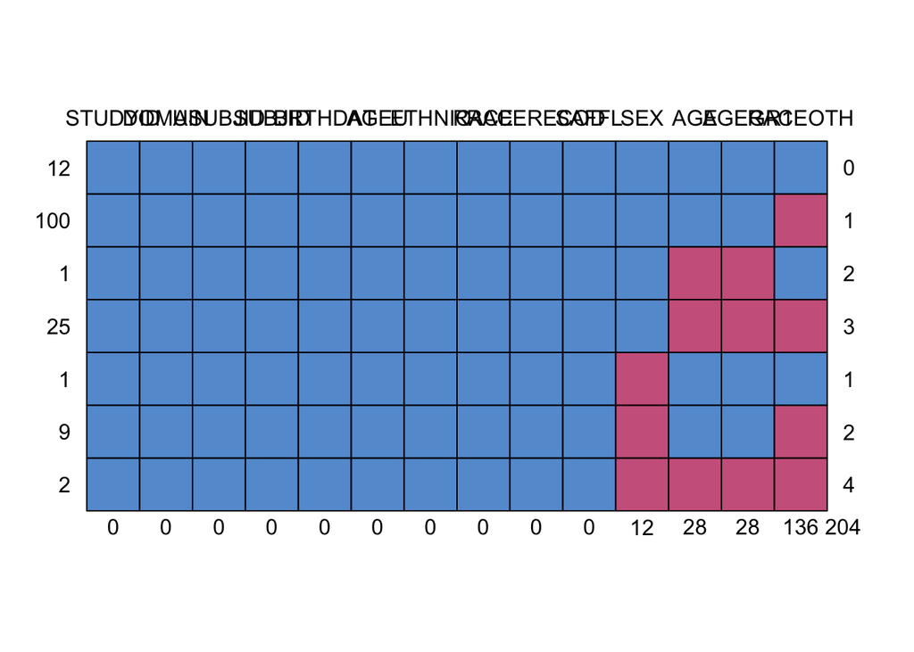

```
    STUDYID DOMAIN USUBJID SUBJID BRTHDAT AGEU ETHNIC RACE RACERECOD SAFFL SEX
12        1      1       1      1       1    1      1    1         1     1   1
100       1      1       1      1       1    1      1    1         1     1   1
1         1      1       1      1       1    1      1    1         1     1   1
25        1      1       1      1       1    1      1    1         1     1   1
1         1      1       1      1       1    1      1    1         1     1   0
9         1      1       1      1       1    1      1    1         1     1   0
2         1      1       1      1       1    1      1    1         1     1   0
          0      0       0      0       0    0      0    0         0     0  12
    AGE AGEGR1 RACEOTH
12    1      1       1   0
100   1      1       0   1
1     0      0       1   2
25    0      0       0   3
1     1      1       1   1
9     1      1       0   2
2     0      0       0   4
     28     28     136 204
```

```r
md.pattern(adam_dm_missing) # mice function for visualizing missingness; matrix and heatmap!
```

**Explanation**: Here, we attempt to map the SDTM DM dataset to an ADaM format while the dataset contains missing values. `AGEGR1`is derived using `case_when()`, and `SAFFL` is flagged using `ifelse()`. This highlights the challenges of creating ADaM datasets when data is incomplete..

### Step 4: Apply Multiple Imputation Using `{mice}`

The methodology behind the `mice()` function in the {mice} package for R is based on **Multivariate Imputation by Chained Equations**. The idea is to create plausible values for missing data in a dataset by treating each variable as a target to be imputed, conditioned on the other variables. The method uses a **Fully Conditional Specification (FCS)**, meaning that each incomplete variable is imputed by a separate model fitted on all other variables iteratively.

**Steps in the Process**:

1. **Imputation**: Replace missing values for each variable using predictive models, specific to the type of data (e.g., predictive mean matching (`pmm`) for numeric variables, logistic regression (`logreg`) for binary categorical variables).
2. **Iteration**: The function cycles through each incomplete variable multiple times to improve the imputation estimates.
3. **Convergence**: After the iterations, a stable solution is expected. Multiple imputations are generated to reflect the uncertainty of the missing data.

The **predictor matrix** specifies which variables to use as predictors for each target variable, and the **method argument** determines the imputation method used, depending on the type of variable (e.g., `pmm`, `logreg`, `polyreg`).

The end result is an `mids`object, containing several imputed datasets, each reflecting different plausible imputations for the missing values, allowing researchers to conduct repeated analyses and account for uncertainty due to missing data.

#### Age

```r
# Add a temporary variable to ensure sufficient columns for imputation
sdtm_dm_missing$temp_id <- seq_len(nrow(sdtm_dm_missing))

# Apply multiple imputation for AGE using the mice package
imp_age <- mice(sdtm_dm_missing %>% select(AGE, temp_id, ETHNIC, RACERECOD), m = 5, maxit = 50, method = "pmm", seed = 500)
# Complete the AGE column using the first imputation
sdtm_dm_imputed_age <- sdtm_dm_missing
sdtm_dm_imputed_age$AGE <- complete(imp_age, 1)$AGE

# Remove the temporary variable
sdtm_dm_imputed_age$temp_id <- NULL

# View the dataset after AGE imputation
head(sdtm_dm_imputed_age)
```

```
        STUDYID DOMAIN              USUBJID SUBJID    BRTHDAT AGE  AGEU SEX
1 CDASH_DEMO_01     DM CDASH_DEMO_01-SUB001 SUB001 1991-08-07  53 Years   F
2 CDASH_DEMO_01     DM CDASH_DEMO_01-SUB002 SUB002 1991-09-24  60 Years   F
3 CDASH_DEMO_01     DM CDASH_DEMO_01-SUB003 SUB003 1948-03-04  32 Years   F
4 CDASH_DEMO_01     DM CDASH_DEMO_01-SUB004 SUB004 1945-01-15  49 Years   F
5 CDASH_DEMO_01     DM CDASH_DEMO_01-SUB005 SUB005 1949-03-24  24 Years   M
6 CDASH_DEMO_01     DM CDASH_DEMO_01-SUB006 SUB006 1971-11-11  24 Years   M
                  ETHNIC                                      RACE RACEOTH
1 NOT HISPANIC OR LATINO                              NOT REPORTED    <NA>
2     HISPANIC OR LATINO NATIVE HAWAIIAN OR OTHER PACIFIC ISLANDER    <NA>
3 NOT HISPANIC OR LATINO                                   UNKNOWN    <NA>
4                UNKNOWN          AMERICAN INDIAN OR ALASKA NATIVE    <NA>
5     HISPANIC OR LATINO                              NOT REPORTED    <NA>
6     HISPANIC OR LATINO                              NOT REPORTED    <NA>
                                  RACERECOD
1                              NOT REPORTED
2 NATIVE HAWAIIAN OR OTHER PACIFIC ISLANDER
3                                   UNKNOWN
4          AMERICAN INDIAN OR ALASKA NATIVE
5                              NOT REPORTED
6                              NOT REPORTED
```

#### Sex

```r
str(sdtm_dm_imputed_age)
```

```
'data.frame':   150 obs. of  12 variables:
 $ STUDYID  : chr  "CDASH_DEMO_01" "CDASH_DEMO_01" "CDASH_DEMO_01" "CDASH_DEMO_01" ...
 $ DOMAIN   : chr  "DM" "DM" "DM" "DM" ...
 $ USUBJID  : chr  "CDASH_DEMO_01-SUB001" "CDASH_DEMO_01-SUB002" "CDASH_DEMO_01-SUB003" "CDASH_DEMO_01-SUB004" ...
 $ SUBJID   : chr  "SUB001" "SUB002" "SUB003" "SUB004" ...
 $ BRTHDAT  : Date, format: "1991-08-07" "1991-09-24" ...
 $ AGE      : int  53 60 32 49 24 24 58 40 44 77 ...
 $ AGEU     : chr  "Years" "Years" "Years" "Years" ...
 $ SEX      : chr  "F" "F" "F" "F" ...
 $ ETHNIC   : chr  "NOT HISPANIC OR LATINO" "HISPANIC OR LATINO" "NOT HISPANIC OR LATINO" "UNKNOWN" ...
 $ RACE     : chr  "NOT REPORTED" "NATIVE HAWAIIAN OR OTHER PACIFIC ISLANDER" "UNKNOWN" "AMERICAN INDIAN OR ALASKA NATIVE" ...
 $ RACEOTH  : chr  NA NA NA NA ...
 $ RACERECOD: chr  "NOT REPORTED" "NATIVE HAWAIIAN OR OTHER PACIFIC ISLANDER" "UNKNOWN" "AMERICAN INDIAN OR ALASKA NATIVE" ...
```

```r
# Add a temporary variable to ensure sufficient columns for imputing SEX
sdtm_dm_imputed_age$temp_id <- seq_len(nrow(sdtm_dm_imputed_age))

# Apply multiple imputation for SEX using logistic regression, using different columns as predictors
imp_sex <- mice(sdtm_dm_imputed_age %>% select(SEX, temp_id, ETHNIC, RACERECOD, AGE), m = 5, maxit = 50, method = "logreg", seed = 500)
```

[output not shown]

[output cut: 235 more lines]

```r
# Complete the SEX column using the first imputation
sdtm_dm_imputed <- sdtm_dm_imputed_age
sdtm_dm_imputed$SEX <- complete(imp_sex, 1)$SEX

# Remove the temporary variable
sdtm_dm_imputed$temp_id <- NULL

# View the dataset after SEX imputation
head(sdtm_dm_imputed)
```

```
        STUDYID DOMAIN              USUBJID SUBJID    BRTHDAT AGE  AGEU SEX
1 CDASH_DEMO_01     DM CDASH_DEMO_01-SUB001 SUB001 1991-08-07  53 Years   F
2 CDASH_DEMO_01     DM CDASH_DEMO_01-SUB002 SUB002 1991-09-24  60 Years   F
3 CDASH_DEMO_01     DM CDASH_DEMO_01-SUB003 SUB003 1948-03-04  32 Years   F
4 CDASH_DEMO_01     DM CDASH_DEMO_01-SUB004 SUB004 1945-01-15  49 Years   F
5 CDASH_DEMO_01     DM CDASH_DEMO_01-SUB005 SUB005 1949-03-24  24 Years   M
6 CDASH_DEMO_01     DM CDASH_DEMO_01-SUB006 SUB006 1971-11-11  24 Years   M
                  ETHNIC                                      RACE RACEOTH
1 NOT HISPANIC OR LATINO                              NOT REPORTED    <NA>
2     HISPANIC OR LATINO NATIVE HAWAIIAN OR OTHER PACIFIC ISLANDER    <NA>
3 NOT HISPANIC OR LATINO                                   UNKNOWN    <NA>
4                UNKNOWN          AMERICAN INDIAN OR ALASKA NATIVE    <NA>
5     HISPANIC OR LATINO                              NOT REPORTED    <NA>
6     HISPANIC OR LATINO                              NOT REPORTED    <NA>
                                  RACERECOD
1                              NOT REPORTED
2 NATIVE HAWAIIAN OR OTHER PACIFIC ISLANDER
3                                   UNKNOWN
4          AMERICAN INDIAN OR ALASKA NATIVE
5                              NOT REPORTED
6                              NOT REPORTED
```

**Explanation**: We use the `mice()` function to perform multiple imputation on the dataset. Five imputed datasets are created using predictive mean matching (`pmm`), and we select the first imputed dataset for further use with the `complete()` function. This step ensures missing values are filled to create a complete dataset, however limitations can be encountered if there is not enough data to create models, which was the case for the `SEX` variable!

### Step 5: Recreate the ADaM Dataset After Imputation

```r
# Derive ADaM Dataset from the imputed SDTM DM Dataset
adam_dm_imputed <- sdtm_dm_imputed %>%
  mutate(
    # Re-create Age Group Variable (AGEGR1)
    AGEGR1 = case_when(
      AGE < 18 ~ "<18",
      AGE >= 18 & AGE <= 65 ~ "18-65",
      AGE > 65 ~ ">65"
    ),
    # Re-create the Safety Population Flag (SAFFL)
    SAFFL = ifelse(SEX %in% c("M", "F"), "Y", "N")
  ) %>%
  select(
    STUDYID, USUBJID, AGE, AGEGR1, SEX, SAFFL, ETHNIC, RACERECOD
  )

# View the final derived ADaM DM dataset after imputation
head(adam_dm_imputed)
```

```
        STUDYID              USUBJID AGE AGEGR1 SEX SAFFL
1 CDASH_DEMO_01 CDASH_DEMO_01-SUB001  53  18-65   F     Y
2 CDASH_DEMO_01 CDASH_DEMO_01-SUB002  60  18-65   F     Y
3 CDASH_DEMO_01 CDASH_DEMO_01-SUB003  32  18-65   F     Y
4 CDASH_DEMO_01 CDASH_DEMO_01-SUB004  49  18-65   F     Y
5 CDASH_DEMO_01 CDASH_DEMO_01-SUB005  24  18-65   M     Y
6 CDASH_DEMO_01 CDASH_DEMO_01-SUB006  24  18-65   M     Y
                  ETHNIC                                 RACERECOD
1 NOT HISPANIC OR LATINO                              NOT REPORTED
2     HISPANIC OR LATINO NATIVE HAWAIIAN OR OTHER PACIFIC ISLANDER
3 NOT HISPANIC OR LATINO                                   UNKNOWN
4                UNKNOWN          AMERICAN INDIAN OR ALASKA NATIVE
5     HISPANIC OR LATINO                              NOT REPORTED
6     HISPANIC OR LATINO                              NOT REPORTED
```

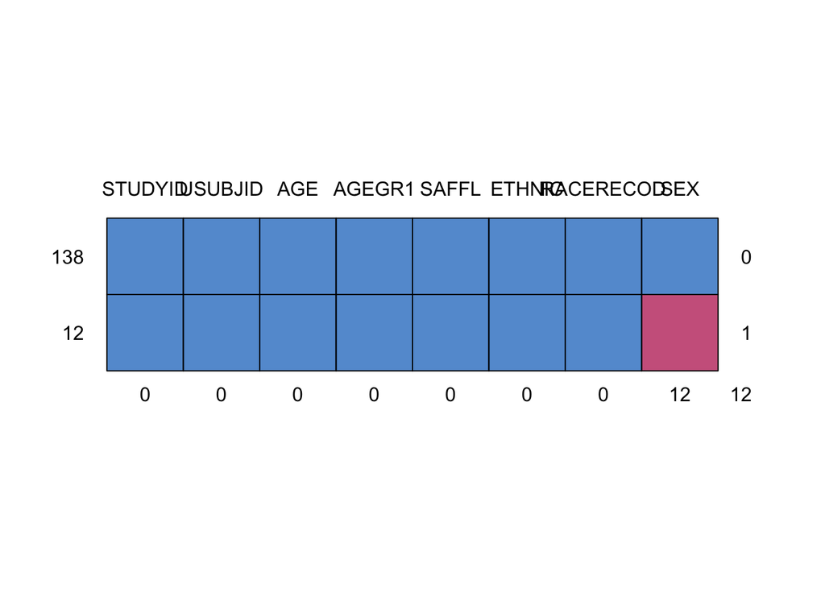

```
    STUDYID USUBJID AGE AGEGR1 SAFFL ETHNIC RACERECOD SEX
138       1       1   1      1     1      1         1   1  0
12        1       1   1      1     1      1         1   0  1
          0       0   0      0     0      0         0  12 12
```

```r
md.pattern(adam_dm_imputed) # mice function for visualizing missingness; matrix and heatmap!
```

### Step 6: Compare Results

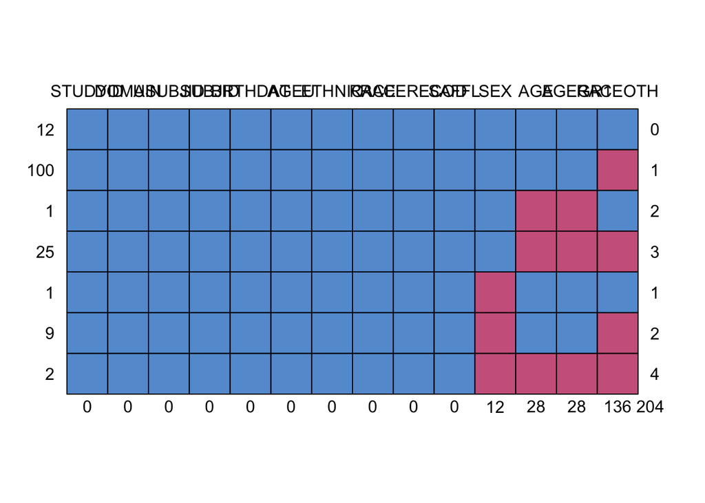

```
    STUDYID DOMAIN USUBJID SUBJID BRTHDAT AGEU ETHNIC RACE RACERECOD SAFFL SEX
12        1      1       1      1       1    1      1    1         1     1   1
100       1      1       1      1       1    1      1    1         1     1   1
1         1      1       1      1       1    1      1    1         1     1   1
25        1      1       1      1       1    1      1    1         1     1   1
1         1      1       1      1       1    1      1    1         1     1   0
9         1      1       1      1       1    1      1    1         1     1   0
2         1      1       1      1       1    1      1    1         1     1   0
          0      0       0      0       0    0      0    0         0     0  12
    AGE AGEGR1 RACEOTH
12    1      1       1   0
100   1      1       0   1
1     0      0       1   2
25    0      0       0   3
1     1      1       1   1
9     1      1       0   2
2     0      0       0   4
     28     28     136 204
```

```r
# Compare original ADaM dataset with missing values to imputed dataset
md.pattern(adam_dm_missing) # mice function for visualizing missingness; matrix and heatmap!
```

```r
anyNA(adam_dm_imputed)
```

```
[1] TRUE
```

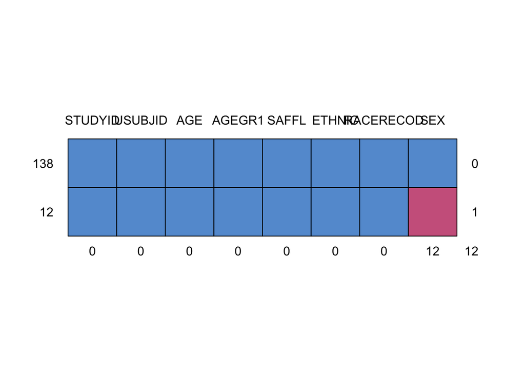

```
    STUDYID USUBJID AGE AGEGR1 SAFFL ETHNIC RACERECOD SEX
138       1       1   1      1     1      1         1   1  0
12        1       1   1      1     1      1         1   0  1
          0       0   0      0     0      0         0  12 12
```

```r
md.pattern(adam_dm_imputed) # mice function for visualizing missingness; matrix and heatmap!
```

```r
# Saving the datasets for future use
saveRDS(sdtm_dm_imputed, "sdtm_dm_imputed.rds") # RDS is a R-specific file format that is in a compressed binary format that retains structure
saveRDS(adam_dm_imputed, "adam_dm_imputed.rds") # RDS is a R-specific file format that is in a compressed binary format that retains structure
```

**Explanation**: We compare the original ADaM dataset containing missing values (`adam_dm_missing`) to the imputed dataset (`adam_dm_imputed`). This comparison helps in understanding the impact of handling missing data on the completeness and reliability of the final analysis-ready dataset.

## Justification for Using `{mice}` for More Complex Analyses

- **Handling Missing Data**: `{mice}` is a powerful package for handling missing data through multiple imputation, which is essential in clinical trial data to ensure valid and unbiased statistical analyses.

## Important CDISC Concepts of SDTM and ADaM that We Are Adhering To During These Processes:

- **Standardization**: Standardizing datasets (ex: DM) across different clinical trials facilitates easier regulatory review and analysis.
- **Traceability**: The derivation of variables like `AGEGR1` and `SAFFL` from SDTM data ensures traceability, which is crucial for CDISC compliance.
- **Handling Missing Data**: Proper handling of missing data is critical in ensuring the accuracy and reliability of analysis results.
- **Metadata Documentation**: Variables in the ADaM dataset must be well-documented with metadata to comply with CDISC standards.
- **Population Flagging**: `SAFFL` helps in defining specific subpopulations for safety analysis, which is a requirement for regulatory submissions.

## Summary of ADaM Creation with Missing Data Handling

This hands-on section helps participants understand how to transform SDTM data into analysis-ready ADaM datasets while handling missing data, emphasizing compliance with CDISC standards for regulatory submissions.